# Reproducible Research PA2

# Analysis of NOAA Storm Database

## Synopsis

The goal of this analysis is to perform a basic exploration of an extract from the National Oceanic and Atmospheric Administration Storm Database, covering the years 1950 through 2011. In particular, I intend to determine and document which weather events have created the greatest costs - both from an economic perspective, and in terms of impact to human health. Going into the investigation - and based on recent history concerning events like Katrina in 2005 and Sandy in 2012 - my belief was that Hurricanes would likely be the most costly weather events. My results for the period 1950 - 2011 indicate that this is true of economic impact; however, in terms of the effect on human health (as determined by number of injuries plus number of fatalities), Tornadoes have proven to be the most harmful.

## Data Processing

The data for this analysis are contained in an extract accessible from this location: https://d396qusza40orc.cloudfront.net/repdata%2Fdata%2FStormData.csv.bz2.

First, we load the necessary packages, and then display the characteristics of our operating environment.

```r
library(data.table)
library(ggplot2)
library(gridExtra)
Sys.info()
```

```
##        sysname        release        version       nodename        machine
##      "Windows"        "7 x64"   "build 9200"       "TIM-PC"       "x86-64"
##          login           user effective_user
##          "Tim"          "Tim"          "Tim"
```

The data are stored in a bzip2 compressed file. We download the file, then read into a data table.

```r
downloadUrl<-"http://d396qusza40orc.cloudfront.net/repdata%2Fdata%2FStormData.csv.bz2"
downloadFile<-"FStormData.csv.bz2"
download.file(downloadUrl,downloadFile)
stormData<-data.table(read.table(downloadFile,sep=",",header=T,stringsAsFactors=F))
```

Let’s display the characteristics of the data:

```r
summary(stormData)
```

```
##     STATE__       BGN_DATE           BGN_TIME          TIME_ZONE
##  Min.   : 1.0   Length:902297      Length:902297      Length:902297
##  1st Qu.:19.0   Class :character   Class :character   Class :character
##  Median :30.0   Mode  :character   Mode  :character   Mode  :character
##  Mean   :31.2
##  3rd Qu.:45.0
##  Max.   :95.0
##
##      COUNTY     COUNTYNAME           STATE              EVTYPE
##  Min.   :  0   Length:902297      Length:902297      Length:902297
##  1st Qu.: 31   Class :character   Class :character   Class :character
##  Median : 75   Mode  :character   Mode  :character   Mode  :character
##  Mean   :101
##  3rd Qu.:131
##  Max.   :873
##
##    BGN_RANGE      BGN_AZI           BGN_LOCATI          END_DATE
##  Min.   :   0   Length:902297      Length:902297      Length:902297
##  1st Qu.:   0   Class :character   Class :character   Class :character
##  Median :   0   Mode  :character   Mode  :character   Mode  :character
##  Mean   :   1
##  3rd Qu.:   1
##  Max.   :3749
##
##    END_TIME           COUNTY_END COUNTYENDN       END_RANGE
##  Length:902297      Min.   :0    Mode:logical   Min.   :  0
##  Class :character   1st Qu.:0    NA's:902297    1st Qu.:  0
##  Mode  :character   Median :0                   Median :  0
##                     Mean   :0                   Mean   :  1
##                     3rd Qu.:0                   3rd Qu.:  0
##                     Max.   :0                   Max.   :925
##
##    END_AZI           END_LOCATI            LENGTH           WIDTH
##  Length:902297      Length:902297      Min.   :   0.0   Min.   :   0
##  Class :character   Class :character   1st Qu.:   0.0   1st Qu.:   0
##  Mode  :character   Mode  :character   Median :   0.0   Median :   0
##                                        Mean   :   0.2   Mean   :   8
##                                        3rd Qu.:   0.0   3rd Qu.:   0
##                                        Max.   :2315.0   Max.   :4400
##
```

[output cut: 25 more lines]

```
##  Min.   :-14451   Min.   :   0   Min.   :-14455   Length:902297
##  1st Qu.:  7247   1st Qu.:   0   1st Qu.:     0   Class :character
##  Median :  8707   Median :   0   Median :     0   Mode  :character
##  Mean   :  6940   Mean   :1452   Mean   :  3509
##  3rd Qu.:  9605   3rd Qu.:3549   3rd Qu.:  8735
##  Max.   : 17124   Max.   :9706   Max.   :106220
##                   NA's   :40
##      REFNUM
##  Min.   :     1
##  1st Qu.:225575
##  Median :451149
##  Mean   :451149
##  3rd Qu.:676723
##  Max.   :902297
##
```

To support the data summarizations, I’m appending the “Year” of each weather event observation to the data table:

```r
stormData$BGN_DATE<-as.Date(stormData$BGN_DATE,format="%m/%d/%Y")
stormData$EV_YEAR<-as.numeric(format(stormData$BGN_DATE,"%Y"))
```

For this analysis, I will be using the sum of FATALITIES and INJURIES to determine the impact to health. Similarly, I am using the sum of PROPDMG and CROPDMG to determine economic impact. This calculation is somewhat more complex, as NOAA documents the fact that “…Alphabetical characters used to signify magnitude include”K" for thousands, “M” for millions, and “B” for billions." Refer to this document for more information: https://d396qusza40orc.cloudfront.net/repdata%2Fpeer2_doc%2Fpd01016005curr.pdf

Here’s the code to come up with the economic and health totals:

```r
stormData$PROP_DMG<-(
        ifelse(stormData$PROPDMGEXP=="H",100,
               ifelse(stormData$PROPDMGEXP=="K",1000,
                      ifelse(stormData$PROPDMGEXP=="M",1000000,
                             ifelse(stormData$PROPDMGEXP=="B",1000000000,1))))*stormData$PROPDMG)
stormData$CROP_DMG<-(
        ifelse(stormData$CROPDMGEXP=="H",100,
               ifelse(stormData$CROPDMGEXP=="K",1000,
                      ifelse(stormData$CROPDMGEXP=="M",1000000,
                             ifelse(stormData$CROPDMGEXP=="B",1000000000,1))))*stormData$CROPDMG)

stormDataSmry<-stormData[,list(SUM_HEALTH=sum(FATALITIES+INJURIES),SUM_ECON=sum(PROP_DMG+CROP_DMG)),by=c("EV_YEAR","EVTYPE")]
```

To facilitate determining which weather event caused the greatest damage in each year, I calculate the maximums of the “HEALTH” and “ECON” sums, and “merge” these to the data table:

```r
stormDataMax<-stormDataSmry[,list(MAX_HEALTH=max(SUM_HEALTH),MAX_ECON=max(SUM_ECON)),by=c("EV_YEAR")]
stormDataSmry<-merge(stormDataSmry,stormDataMax,by=c("EV_YEAR"))
```

Now let’s see what the data look like:

```r
summary(stormDataSmry)
```

```
##     EV_YEAR        EVTYPE            SUM_HEALTH      SUM_ECON
##  Min.   :1950   Length:2326        Min.   :   0   Min.   :0.00e+00
##  1st Qu.:1995   Class :character   1st Qu.:   0   1st Qu.:0.00e+00
##  Median :1997   Mode  :character   Median :   0   Median :1.35e+03
##  Mean   :1997                      Mean   :  67   Mean   :2.05e+08
##  3rd Qu.:2001                      3rd Qu.:   5   3rd Qu.:1.17e+06
##  Max.   :2011                      Max.   :7190   Max.   :1.17e+11
##    MAX_HEALTH      MAX_ECON
##  Min.   : 418   Min.   :3.45e+07
##  1st Qu.: 767   1st Qu.:2.36e+09
##  Median :1139   Median :3.72e+09
##  Mean   :1573   Mean   :7.72e+09
##  3rd Qu.:1616   3rd Qu.:5.54e+09
##  Max.   :7190   Max.   :1.17e+11
```

This yields an interesting result. I observe that the maximum value of “MAX_ECON” is 1.166e+11 - or 116.6 BILLION. That seems awfully large for a single year. I am curious, so I display the row that contains this value:

```r
stormData[stormData$PROP_DMG==max(stormData$PROP_DMG),]
```

```
##    STATE__   BGN_DATE    BGN_TIME TIME_ZONE COUNTY COUNTYNAME STATE EVTYPE
## 1:       6 2006-01-01 12:00:00 AM       PST     55       NAPA    CA  FLOOD
##    BGN_RANGE BGN_AZI BGN_LOCATI         END_DATE    END_TIME COUNTY_END
## 1:         0         COUNTYWIDE 1/1/2006 0:00:00 07:00:00 AM          0
##    COUNTYENDN END_RANGE END_AZI END_LOCATI LENGTH WIDTH  F MAG FATALITIES
## 1:         NA         0         COUNTYWIDE      0     0 NA   0          0
##    INJURIES PROPDMG PROPDMGEXP CROPDMG CROPDMGEXP WFO          STATEOFFIC
## 1:        0     115          B    32.5          M MTR CALIFORNIA, Western
##    ZONENAMES LATITUDE LONGITUDE LATITUDE_E LONGITUDE_
## 1:               3828     12218       3828      12218
##                                                                                                                                                                                                                                                                                                          …
## 1: Major flooding continued into the early hours of January 1st, before the Napa River finally fell below flood stage and the water receeded. Flooding was severe in Downtown Napa from the Napa Creek and the City and Parks Department was hit with $6 million in damage alone. The City of Napa had 60…
##    REFNUM EV_YEAR PROP_DMG CROP_DMG
## 1: 605943    2006 1.15e+11 32500000
```

This was a Napa Valley flood in 2006. The “REMARKS” speak of damage in the millions of dollars. I have a hunch that perhaps the “PROPDMGEXP” and/or “CROPDMGEXP” value may be incorrect:

```r
stormData$PROPDMGEXP[stormData$PROP_DMG==max(stormData$PROP_DMG)]
```

```
## [1] "B"
```

```r
stormData$CROPDMGEXP[stormData$PROP_DMG==max(stormData$PROP_DMG)]
```

```
## [1] "M"
```

I observe that the “PROPDMGEXP” value is “B”. Based on the “REMARKS” information, and also bolstered by information attained from the Internet(including this report that cites damage over 36 years from 19 floods yielded some $542 MILLION in property damage: https://www.llis.dhs.gov/content/napa-river-flood-protection-project), I change the value of PROPDMGEXP to “M”, and rebuild my summary data table:

```r
stormData$PROPDMGEXP[stormData$PROP_DMG==max(stormData$PROP_DMG)]<-"M"
stormData$PROP_DMG<-(
        ifelse(stormData$PROPDMGEXP=="H",100,
               ifelse(stormData$PROPDMGEXP=="K",1000,
                      ifelse(stormData$PROPDMGEXP=="M",1000000,
                             ifelse(stormData$PROPDMGEXP=="B",1000000000,1))))*stormData$PROPDMG)
stormData$CROP_DMG<-(
        ifelse(stormData$CROPDMGEXP=="H",100,
               ifelse(stormData$CROPDMGEXP=="K",1000,
                      ifelse(stormData$CROPDMGEXP=="M",1000000,
                             ifelse(stormData$CROPDMGEXP=="B",1000000000,1))))*stormData$CROPDMG)

stormDataSmry<-stormData[,list(SUM_HEALTH=sum(FATALITIES+INJURIES),SUM_ECON=sum(PROP_DMG+CROP_DMG)),by=c("EV_YEAR","EVTYPE")]
stormDataMax<-stormDataSmry[,list(MAX_HEALTH=max(SUM_HEALTH),MAX_ECON=max(SUM_ECON)),by=c("EV_YEAR")]
stormDataSmry<-merge(stormDataSmry,stormDataMax,by=c("EV_YEAR"))
```

Let’s display the characteristics of the updated data table:

```r
summary(stormDataSmry)
```

```
##     EV_YEAR        EVTYPE            SUM_HEALTH      SUM_ECON
##  Min.   :1950   Length:2326        Min.   :   0   Min.   :0.00e+00
##  1st Qu.:1995   Class :character   1st Qu.:   0   1st Qu.:0.00e+00
##  Median :1997   Mode  :character   Median :   0   Median :1.35e+03
##  Mean   :1997                      Mean   :  67   Mean   :1.55e+08
##  3rd Qu.:2001                      3rd Qu.:   5   3rd Qu.:1.17e+06
##  Max.   :2011                      Max.   :7190   Max.   :5.18e+10
##    MAX_HEALTH      MAX_ECON
##  Min.   : 418   Min.   :3.45e+07
##  1st Qu.: 767   1st Qu.:2.36e+09
##  Median :1139   Median :3.72e+09
##  Mean   :1573   Mean   :5.26e+09
##  3rd Qu.:1616   3rd Qu.:5.20e+09
##  Max.   :7190   Max.   :5.18e+10
```

The maximum value of “MAX_ECON” is now 5.180e+10 (51.8 BILLION).

## Results

First, I subset the summary table, to present a “health” summary and an “economic” summary. These are used to present the event in each year that yielded the greatest impact, based on those categories:

```r
healthSmry<-subset(stormDataSmry,SUM_HEALTH==MAX_HEALTH,select=c("EV_YEAR","EVTYPE","SUM_HEALTH"))
econSmry<-subset(stormDataSmry,SUM_ECON==MAX_ECON,select=c("EV_YEAR","EVTYPE","SUM_ECON"))
maxeconSmry<-econSmry[econSmry$SUM_ECON==max(econSmry$SUM_ECON),]
maxhealthSmry<-healthSmry[healthSmry$SUM_HEALTH==max(healthSmry$SUM_HEALTH),]
```

Using the ggplot2 and gridExtra packages, I create and display the plots showing the events yielding maximum damages per year:

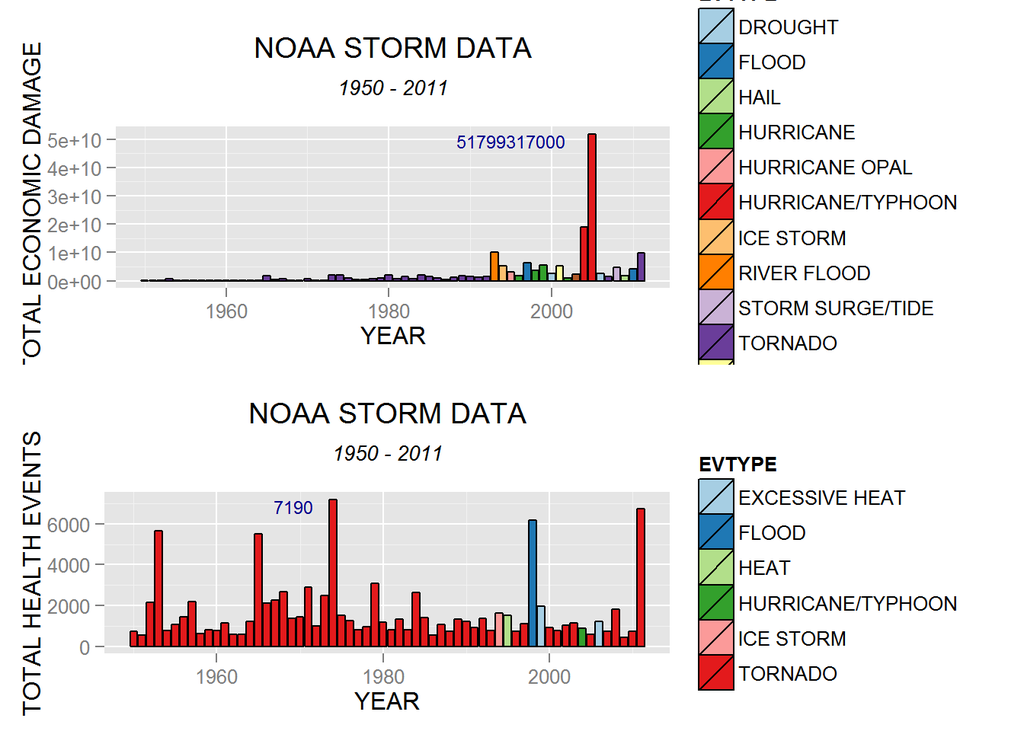

```r
phealthSmry<-ggplot(healthSmry[order(EV_YEAR)],aes(x=EV_YEAR,y=SUM_HEALTH,fill=EVTYPE))+geom_bar(color="black",stat="identity",position=position_dodge())+ggtitle(expression(atop("NOAA STORM DATA", atop(italic("1950 - 2011"), ""))))+xlab("YEAR")+ylab("TOTAL HEALTH EVENTS")+scale_fill_brewer(palette="Paired")+geom_text(data = maxhealthSmry, aes(label=SUM_HEALTH),hjust=1.5, vjust=1,size=3,color="blue4")
peconSmry<-ggplot(econSmry[order(EV_YEAR)],aes(x=EV_YEAR,y=SUM_ECON,fill=EVTYPE))+geom_bar(color="black",stat="identity",position=position_dodge())+ggtitle(expression(atop("NOAA STORM DATA", atop(italic("1950 - 2011"), ""))))+xlab("YEAR")+ylab("TOTAL ECONOMIC DAMAGE")+scale_fill_brewer(palette="Paired")+geom_text(data = maxeconSmry, aes(label=SUM_ECON),hjust=1.25, vjust=1,size=3,color="blue4")
grid.arrange(peconSmry,phealthSmry,nrow=2)
```

From these plots, it is clear to see that Tornadoes have had the greatest impact on health. As for economic impact, the single greatest event was a hurricane (2005 - presumably, Katrina); however, over the duration of this dataset, there has been a prevalance of Tornadoes being reported as having he highest economic impact per year. Therefore, we’ll summarize by event, and present the top 5 events causing damage per category (health vs. economic):

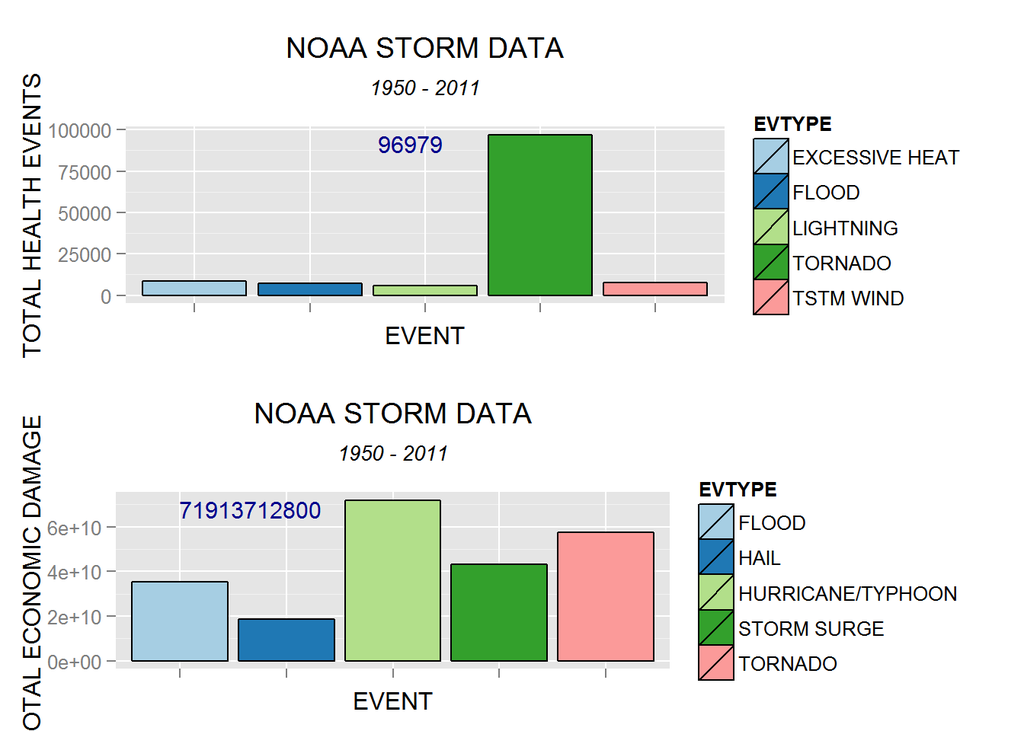

```r
stormDataTot<-stormDataSmry[,list(TOT_HEALTH=sum(SUM_HEALTH),TOT_ECON=sum(SUM_ECON)),by=c("EVTYPE")]
maxeconTot<-stormDataTot[stormDataTot$TOT_ECON==max(stormDataTot$TOT_ECON),]
maxhealthTot<-stormDataTot[stormDataTot$TOT_HEALTH==max(stormDataTot$TOT_HEALTH),]
top5health<-stormDataTot[order(TOT_HEALTH,decreasing=T),][1:5]
top5econ<-stormDataTot[order(TOT_ECON,decreasing=T),][1:5]
ptop5health<-ggplot(top5health[order(TOT_HEALTH)],aes(x=EVTYPE,y=TOT_HEALTH,fill=EVTYPE))+geom_bar(color="black",stat="identity",position=position_dodge())+ggtitle(expression(atop("NOAA STORM DATA", atop(italic("1950 - 2011"), ""))))+xlab("EVENT")+ylab("TOTAL HEALTH EVENTS")+scale_fill_brewer(palette="Paired")+geom_text(data = maxhealthTot, aes(label=TOT_HEALTH),hjust=2.5, vjust=1,size=4,color="blue4")+theme(axis.text.x = element_blank())
ptop5econ<-ggplot(top5econ[order(TOT_ECON)],aes(x=EVTYPE,y=TOT_ECON,fill=EVTYPE))+geom_bar(color="black",stat="identity",position=position_dodge())+ggtitle(expression(atop("NOAA STORM DATA", atop(italic("1950 - 2011"), ""))))+xlab("EVENT")+ylab("TOTAL ECONOMIC DAMAGE")+scale_fill_brewer(palette="Paired")+geom_text(data = maxeconTot, aes(label=TOT_ECON),hjust=1.5, vjust=1,size=4,color="blue4")+theme(axis.text.x = element_blank())
grid.arrange(ptop5health,ptop5econ,nrow=2)
```

From these plots, we draw our conclusions:

For the period 1950 - 2011, based on the NOAA data, Tornadoes have had the greatest impact to health (in terms of FATALITIES and INJURIES), and Hurricanes have caused the greatest economic damage.